# Amazon_deliveries

Amazon releases updates on drone delivery, robots, and packaging (aboutamazon.com)  
This task has a fictional Drone delivery dataset, which has collected x and y coordinates of locations from which purchases are ordered.

1. The task is to determine the most optimal delivery points for products using clustering methods.  
a. Investigate what the optimal number of clusters would be.

Generate 50 ramdom locations in Finland

```python
import numpy as np
import pandas as pd
from sklearn.cluster import KMeans, AgglomerativeClustering
from timeit import default_timer
import matplotlib.pyplot as plt
import seaborn as sns
```

The following code generates 50 random locations

```python
# Generate 50 ramdom locations in Finland

import geopandas as gpd

# Load the Natural Earth 'low resolution' world dataset
world = gpd.read_file(
    "https://raw.githubusercontent.com/nvkelso/natural-earth-vector/master/geojson/ne_110m_admin_0_countries.geojson"
)

print(world.columns)

# load world map
#world = gpd.read_file(gpd.datasets.get_path("naturalearth_lowres"))

# extract Finland polygon
finland = world[world["ADMIN"] == "Finland"]
finland_shape = finland.geometry.iloc[0]

from shapely.geometry import Point
import random

def random_point_in_polygon(polygon):
    minx, miny, maxx, maxy = polygon.bounds
    while True:
        # random lon, lat
        x = random.uniform(minx, maxx)
        y = random.uniform(miny, maxy)
        point = Point(x, y)
        if polygon.contains(point):
            return point

# generate N random points
N = 50
points = [random_point_in_polygon(finland_shape) for _ in range(N)]

# convert to a GeoDataFrame

locations_df = gpd.GeoDataFrame(geometry=points)
locations_df["Longitude"] = locations_df.geometry.x
locations_df["Latitude"] = locations_df.geometry.y
```

```
Index(['featurecla', 'scalerank', 'LABELRANK', 'SOVEREIGNT', 'SOV_A3',
       'ADM0_DIF', 'LEVEL', 'TYPE', 'TLC', 'ADMIN',
       ...
       'FCLASS_TR', 'FCLASS_ID', 'FCLASS_PL', 'FCLASS_GR', 'FCLASS_IT',
       'FCLASS_NL', 'FCLASS_SE', 'FCLASS_BD', 'FCLASS_UA', 'geometry'],
      dtype='object', length=169)
```

```python
print(locations_df.dtypes)  # Locations:df has 3 columns
print("")
print(locations_df.head(5))
```

```
geometry     geometry
Longitude     float64
Latitude      float64
dtype: object

                    geometry  Longitude   Latitude
0   POINT (28.25827 62.9446)  28.258265  62.944605
1   POINT (29.2864 63.38665)  29.286404  63.386647
2  POINT (23.82743 63.83464)  23.827428  63.834636
3  POINT (24.33601 64.32632)  24.336010  64.326316
4  POINT (26.42758 65.89304)  26.427577  65.893037
```

Use the Elbow graph to determine the optimal number of clusters

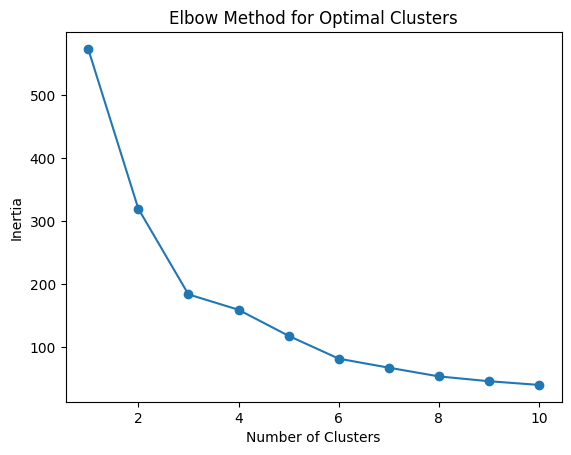

```python
import numpy as np
import matplotlib.pyplot as plt
from sklearn.cluster import KMeans

# Assuming you have your DataFrame with 'Latitude' and 'Longitude'
# Here, clients_df is your DataFrame containing the x (Latitude) and y (Longitude) coordinates

# Range of number of clusters to try (1 to 10 for this example)
cluster_range = range(1, 11)
inertia = []

# Calculate inertia for each value of k
for k in cluster_range:
    kmeans = KMeans(n_clusters=k, random_state=42)
    kmeans.fit(locations_df[['Latitude', 'Longitude']])
    inertia.append(kmeans.inertia_)

# Plot inertia vs number of clusters
plt.plot(cluster_range, inertia, marker='o')
plt.xlabel('Number of Clusters')
plt.ylabel('Inertia')
plt.title('Elbow Method for Optimal Clusters')
plt.show()
```

Use Silhoutte graph to determine the number of optimal clusters

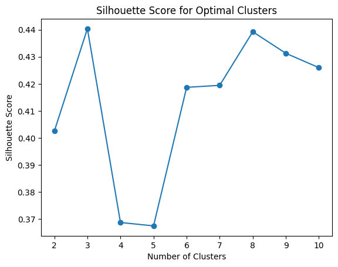

```python
from sklearn.metrics import silhouette_score

# Calculate the silhouette score for each number of clusters
sil_scores = []

for k in cluster_range[1:]:  # Start from 2 clusters, as silhouette score is undefined for 1 cluster
    kmeans = KMeans(n_clusters=k, random_state=42)
    kmeans.fit(locations_df[['Latitude', 'Longitude']])
    sil_score = silhouette_score(locations_df[['Latitude', 'Longitude']], kmeans.labels_)
    sil_scores.append(sil_score)

# Plot silhouette scores
plt.plot(cluster_range[1:], sil_scores, marker='o')
plt.xlabel('Number of Clusters')
plt.ylabel('Silhouette Score')
plt.title('Silhouette Score for Optimal Clusters')
plt.show()
```

b. Then, for each customer, determine the closest delivery point to each. In other words, create a new table  
with both the customer coordinates and the cluster value as the third column. Print the first few rows.

b. Then, for each customer, determine the closest delivery point to each. In other words, create a new table  
with both the customer coordinates and the cluster value as the third column. Print the first few rows.

```python
from sklearn.cluster import KMeans

def run_kmeans2(locations_df, k):
    """
    Run KMeans clustering on a dataframe with 'Latitude' and 'Longitude'.
    Returns a new dataframe with cluster labels and the cluster centers.
    """

    # Work on a copy
    df_copy = locations_df.copy()

    # Safely remove old cluster column if present
    df_copy = df_copy.drop(columns=["cluster"], errors="ignore")

    # Fit model
    kmeans = KMeans(n_clusters=k, random_state=42)
    kmeans.fit(df_copy[['Latitude', 'Longitude']])

    # Add clusters
    df_copy['cluster'] = kmeans.labels_

    return df_copy, kmeans.cluster_centers_
```

```python
from sklearn.cluster import KMeans
import numpy as np

def run_kmeans_basic(locations_df, k):
    """
    Runs KMeans clustering on the given dataframe using Longitude and Latitude.

    Parameters:
        locations_df (pd.DataFrame): DataFrame with 'Longitude' and 'Latitude' columns.
        k (int): Number of clusters.

    Returns:
        X (ndarray): Original coordinate array.
        cluster_pred (ndarray): Cluster labels for each point.
        cluster_center (ndarray): Coordinates of cluster centers.
    """

    # Extract coordinates as a NumPy array
    X = locations_df[["Longitude", "Latitude"]].values

    # Run KMeans
    kmeans1 = KMeans(n_clusters=k, random_state=42)
    kmeans1.fit(X)

    # Predictions and cluster centers
    cluster_pred = kmeans1.predict(X)
    cluster_center = kmeans1.cluster_centers_

    return X, cluster_pred, cluster_center
```

```python
import pandas as pd

def create_centroids_df(locations_df, cluster_centers):
    """
    Creates a DataFrame for cluster centers using the same column names
    as the original coordinate columns.

    Parameters:
        locations_df (pd.DataFrame): Original dataframe with 'Longitude' and 'Latitude'.
        cluster_centers (array-like): Numpy array of cluster center coordinates.

    Returns:
        pd.DataFrame: DataFrame containing the cluster centers.
    """

    # Extract the column names used for coordinates
    colnames = locations_df[["Longitude", "Latitude"]].columns

    # Create the DataFrame
    centroids_df = pd.DataFrame(cluster_centers, columns=colnames)

    return centroids_df
```

```python
import matplotlib.pyplot as plt
import geopandas as gpd
from shapely.geometry import Point
import seaborn as sns

def plot_finland_clusters2(locations_df, cluster_centers, world_df):
    """
    Plots the Finland outline, the clustered points,
    and the cluster centers with colorful visualization.
    """

    # Extract Finland polygon
    finland = world_df[world_df['ADMIN'] == 'Finland']

    # Convert to GeoDataFrame
    points = gpd.GeoDataFrame(
        locations_df,
        geometry=[Point(xy) for xy in zip(locations_df["Longitude"], locations_df["Latitude"])],
        crs="EPSG:4326"
    )

    # Create plot
    fig, ax = plt.subplots(figsize=(12, 14))

    # --- Plot Finland outline ---
    finland.boundary.plot(ax=ax, edgecolor='black', linewidth=1.2)

    # --- Colorful cluster plotting ---
    unique_clusters = sorted(points["cluster"].unique())
    palette = sns.color_palette("tab10", len(unique_clusters))

    for cluster_id, color in zip(unique_clusters, palette):
        cluster_points = points[points["cluster"] == cluster_id]
        cluster_points.plot(
            ax=ax,
            color=color,
            markersize=20,
            label=f"Cluster {cluster_id}"
        )

    # --- Cluster centers with nice styling ---
    plt.scatter(
        cluster_centers[:, 0],
        cluster_centers[:, 1],
        s=250,
        c="yellow",
        edgecolors="black",
        linewidth=1.5,
        marker='X',
        label="Cluster Centers"
    )

    # --- Zoom around Finland ---
    minx, miny, maxx, maxy = finland.total_bounds
    ax.set_xlim(minx - 2, maxx + 2)
    ax.set_ylim(miny - 2, maxy + 2)

    # Titles & labels
    ax.set_title("Clustered Delivery Points in Finland", fontsize=16)
    ax.set_xlabel("Longitude", fontsize=12)
    ax.set_ylabel("Latitude", fontsize=12)

    ax.legend(title="Legend")

    plt.show()
```

```python
""" df_new, centers = run_kmeans(locations_df, 3)
print(df_new.head())
print(df_new['cluster'].unique())

print(locations_df.columns.tolist()) """
```

```
" df_new, centers = run_kmeans(locations_df, 3)\nprint(df_new.head())\nprint(df_new['cluster'].unique())\n\nprint(locations_df.columns.tolist()) "
```

```
                    geometry  Longitude   Latitude  cluster
0   POINT (28.25827 62.9446)  28.258265  62.944605        3
1   POINT (29.2864 63.38665)  29.286404  63.386647        3
2  POINT (23.82743 63.83464)  23.827428  63.834636        2
3  POINT (24.33601 64.32632)  24.336010  64.326316        2
4  POINT (26.42758 65.89304)  26.427577  65.893037        4
5  POINT (27.01269 65.43272)  27.012685  65.432724        4
6  POINT (27.54087 68.34554)  27.540870  68.345545        0
7  POINT (25.27624 62.59685)  25.276238  62.596845        1
8  POINT (27.67476 67.46079)  27.674761  67.460793        4
9   POINT (24.44374 63.0079)  24.443742  63.007900        2

Cluster centers:
[[68.36900302 25.25933428]
 [61.51597296 25.76646045]
 [63.22806313 23.52886782]
 [62.84542841 28.75701612]
 [65.83550063 27.05080939]]
X coordinates:
[[28.25826521 62.94460464]
 [29.28640384 63.38664665]
 [23.82742808 63.83463597]
 [24.33601025 64.32631555]
 [26.42757664 65.89303708]
 [27.01268546 65.43272446]
 [27.54086989 68.34554487]
 [25.27623844 62.59684507]
 [27.67476073 67.46079281]
 [24.44374235 63.00790015]
 [28.23131211 61.99951878]
 [26.09192984 64.49951333]
 [24.61653906 62.40947091]
 [27.26422698 63.7511372 ]
 [24.11790132 63.8350583 ]
 [24.27842135 68.271356  ]
 [25.59859479 61.22824109]
 [30.84108504 62.88488706]
 [26.28397318 69.1803481 ]
 [23.451146   68.46713046]
 [25.67057396 66.03040196]
```

[output cut: 18 more lines]

```
 [24.02557073 68.14456533]
 [27.34432469 68.14667555]
 [28.45192877 61.31828323]
 [27.94775488 66.92356491]
 [22.78200652 68.44720706]
 [28.30660738 66.45279498]
 [27.65301379 63.11797193]
 [29.44113778 65.81161013]
 [26.95292199 60.69308189]
 [26.55615396 62.79286439]
 [24.9023976  64.22751118]]

Cluster predictions:
[3 3 2 2 4 4 0 1 4 2 3 4 2 3 2 0 1 3 0 0 4 2 1 2 0 3 4 2 0 3 0 1 0 2 4 3 3
 4 3 0 0 3 4 0 4 3 4 1 1 2]
```

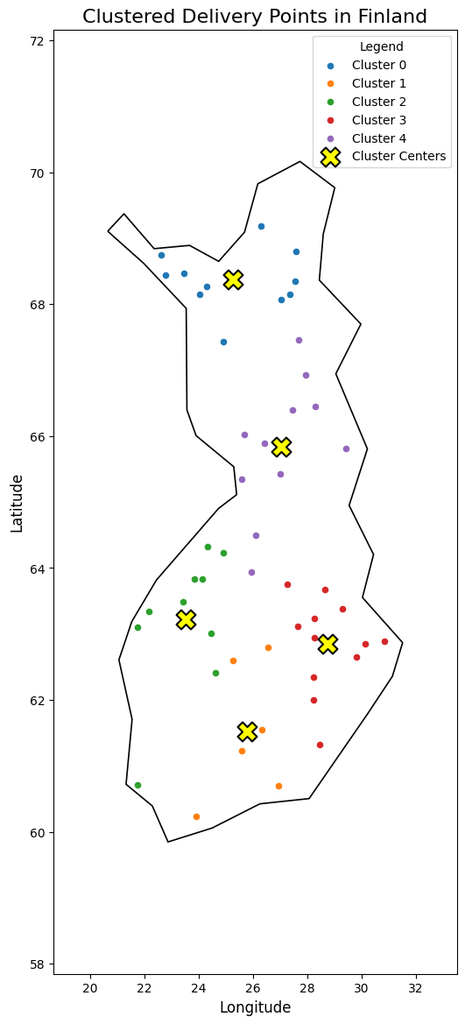

```python
k = 5


df_clusters, centers = run_kmeans2(locations_df, k)


print(df_clusters.head(10))
print("\nCluster centers:")
print(centers)

X, cluster_pred, cluster_center = run_kmeans_basic(locations_df, k)

print("X coordinates:")
print(X)

print("\nCluster predictions:")
print(cluster_pred)

#plot_finland_clusters(locations_df, cluster_center, world)

plot_finland_clusters2(df_clusters, cluster_center, world)
```

2. Tehtävänä on vertailla kahta eri klusterointimetodia kmeans ja hierarkkisista agglomerative

```python
def run_clustering(model, data):
    start = default_timer()
    labels = model.fit_predict(data)
    end = default_timer()
    elapsed = end - start
    return labels, elapsed
```

```python
def compare_kmeans_vs_agglomerative(data, k):

    print(f"\n=== Comparing KMeans and Agglomerative for k={k} ===")

    # --- Run KMeans ---
    kmeans = KMeans(n_clusters=k, random_state=42)
    kmeans_labels, kmeans_time = run_clustering(kmeans, data)

    # --- Run Agglomerative ---
    agg = AgglomerativeClustering(n_clusters=k)
    agg_labels, agg_time = run_clustering(agg, data)

    # --- Visualization ---
    fig, ax = plt.subplots(1, 2, figsize=(14, 6))

    sns.scatterplot(
        x=data[:,0], y=data[:,1],
        hue=kmeans_labels,
        palette="tab10",
        ax=ax[0]
    )
    ax[0].set_title(f"KMeans Clustering (k={k})")
    ax[0].legend().remove()

    sns.scatterplot(
        x=data[:,0], y=data[:,1],
        hue=agg_labels,
        palette="tab10",
        ax=ax[1]
    )
    ax[1].set_title(f"Agglomerative Clustering (k={k})")
    ax[1].legend().remove()

    plt.show()

    # --- Print timing ---
    print(f"KMeans time:          {kmeans_time:.6f} seconds")
    print(f"Agglomerative time:   {agg_time:.6f} seconds")

    # --- Conclusions (automatic) ---
    print("\n--- Automatic Observations ---")

    if kmeans_time < agg_time:
        print("* KMeans was faster.")
    else:
        print("* Agglomerative was faster.")

    if len(np.unique(kmeans_labels)) != len(np.unique(agg_labels)):
        print("* The methods produced a different number of clusters (unexpected).")

    print("* You can visually compare how compact / spread out clusters are in the plots.")
```

```
=== Comparing KMeans and Agglomerative for k=3 ===
```

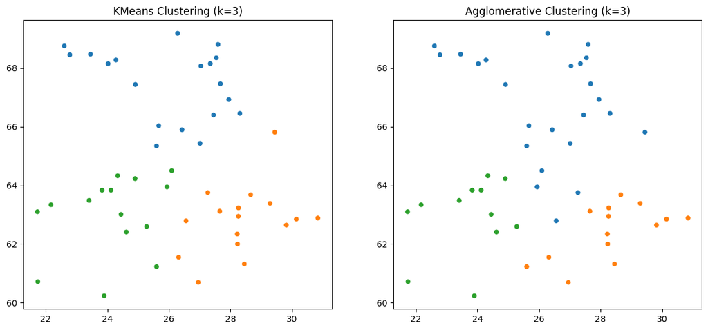

```
KMeans time:          0.005544 seconds
Agglomerative time:   0.002514 seconds

--- Automatic Observations ---
* Agglomerative was faster.
* You can visually compare how compact / spread out clusters are in the plots.

=== Comparing KMeans and Agglomerative for k=5 ===
```

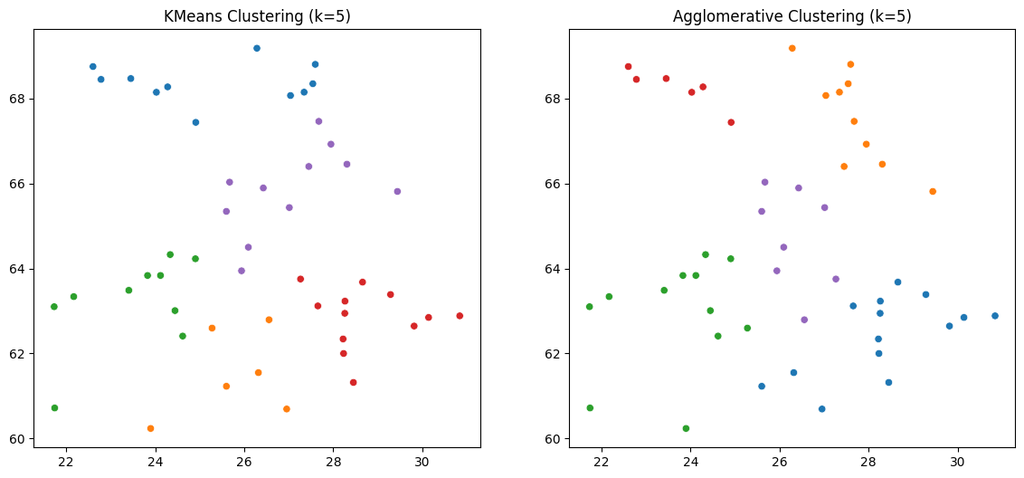

```
KMeans time:          0.003599 seconds
Agglomerative time:   0.001037 seconds

--- Automatic Observations ---
* Agglomerative was faster.
* You can visually compare how compact / spread out clusters are in the plots.

=== Comparing KMeans and Agglomerative for k=8 ===
```

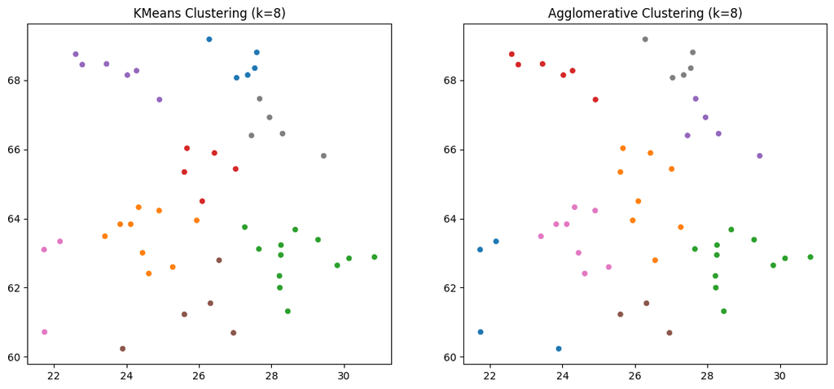

```
KMeans time:          0.004763 seconds
Agglomerative time:   0.000901 seconds

--- Automatic Observations ---
* Agglomerative was faster.
* You can visually compare how compact / spread out clusters are in the plots.
```

```python
data = locations_df[["Longitude", "Latitude"]].values

compare_kmeans_vs_agglomerative(data, k=3)
compare_kmeans_vs_agglomerative(data, k=5)
compare_kmeans_vs_agglomerative(data, k=8)
```